# Estimacin con R . Actividad 1

Carlos Caizares

12 de Agosto 19

Suponiendo que de cierta forma he logrado reconocer la familia a la que pertenece el modelo que pueda ajustar a los datos que estoy ibservando, el paso importante que sigue es determinar concretamente cul de los modelos de esta familia es el que se ajusta a nuestra informacin. Es decir, necesitamos tcnicas para lograr estimar los parmetros de este modelo particular.

## Mtodos de estimacin

Existen diversos mtodos para estimar los parmetros de una distribucin, los ms usuales encontrados son:

### Mtodo de momentos.

Este mtodo propuesto por Karl Pearson $\approx 1900$ que expresa:

Supongamos que observamos los valores de una muestra aleatoria $x_1,x_2,...,x_n$ de una distribucin $F(x|\theta)$, donde $\theta=(\theta_1,\theta_2,...,\theta_r)$ es un vector de $r$ parmetros. Denotando a $\mu_k(\theta)=\mathbb{E}[X^k|\theta]$, el $k-<e9>simo$ momento poblacional, es decir:

$$\mu_k(\theta)=\mathbb{E}[X^k|\theta]=\int x^k f(x) dx$$

Y por:

$$M_k = \frac{1}{n} \sum_{i=1}^{n}x_{i}^{k}$$

el correspondiente $k-<e9>simo$ momento muestral.

El mtodo de momentos consiste en igualar los primeros $r$ momentos poblacionales a sus correspondientes $r$ momentos muestrales y resolver el sistema de ecuaciones simultneas que resulte, es decir:

$$\mu_k(\theta)= \frac{1}{n} \sum_{i=1}^{n}x_{i}^{k} \hspace{5em} k=1,2,...,r$$
Este sistema tendr como soluciones a los estimadores $\hat{\theta}=(\hat{\theta_1},\hat{\theta_2},...,\hat{\theta_r},)$

### Ejemplo de la Normal($\mu$,$\sigma^2$)

Como en este caso tenemos dos parmetros, entonces tenemos dos ecuaciones, por ello:

$$\mu_1=\mu_1(\mu,\sigma^2)=\mathbb{E}[X]=\mu=\bar{x}$$

Por lo tanto
$$\hat{\mu}=\bar{x}$$

Luego

$$\displaystyle \mu_2=\mu_2(\mu,\sigma^2)=\mathbb{E}[X^2]=\sigma^2+\mu^2=\frac{1}{n}\sum_{i=1}^{n}x_{i}^{2}$$

as

$$\displaystyle \sigma^2=\frac{1}{n}\sum_{i=1}^{n}x_{i}^{2}-\mu^2=\frac{1}{n}\sum_{i=1}^{n}x_{i}^{2}-\bar{x}^2=\frac{1}{n}\sum_{i=1}^{n}(x_{i}-\bar{x})^2$$

Es decir:

$$\hat{\sigma^2}=\frac{1}{n}\sum_{i=1}^{n}(x_{i}-\bar{x})^2 \hspace{2em} No \ es\ S^2$$

por lo tanto, los estimador por momentos de ambos parmetros son:

$$\left ( \hat{\mu}=\frac{1}{n}\sum_{i=1}^{n}x_{i} \ \ , \ \ \hat{\sigma^2}=\frac{1}{n}\sum_{i=1}^{n}(x_{i}-\bar{x})^2 \right )$$

### Mtodo por mxima verosimilitud.

Es quizs el mtodo ms comn y utilizado para estimar parmetros. Definiendo la *verosimilitud* como la distribucin conjunta de la muestra. Si los datos llegasen a ser continuos, esta es propiamente una funcin de distrivucin conjunta, y en caso de que sean discretos, es una cuncin conjunta de probabilidad.

Es importante notar que necesitas proceder a maximizar dicha *verosimilitud* con respecto a los parmetros de inters. Los valores de los parmetros que la maximizan son los *estimacores mximo varosmiles*. Debido al hecho comn de que las observaciones se suponen *independientes e identimcamente distribuidas (i.i.d)* la forma de la verosimilitud es de la forma:

$$L(\theta,\underline{X})=\prod_{i=1}^{n}f(x_i|\theta)$$
Generalmente la verosmilitud no se maximiza, y tulizamos el logaritmo de la misma (conocida como la *log - verosimilitud*)

$$\mathcal{l}(\theta,\underline{X})= log[] L(\theta,\underline{X})]=\sum_{i=1}^{n}logf(x_i|\theta)$$
Esto podemos hacerlo dado que el punto donde se alcanza el mximo versimil es el mismo que se alcanza con la *log-verosimilitud* dado que la funcin logaritmo es una funcin montona creciente.

Adicional, los estimadores mximo verosmiles tienen varias de las propiedades que deseamos en un buen estimador (insesgamiento, consistencia, eficiencia) aunque algunas de ellas slo lo alcanzan de forma asinttica.

Adicional, una de las caractersticas ms importantes de dicho estimador es que este tiene una distribucin asinttica normal.

$$\hat{\theta}_{MV} \overset{a}{\sim} N(\theta,\hat{var}(\hat{\theta}_{MV}))$$

Existen otros dos mtodos importantes para estimar parmetros:

- Mtodo de estimacin de parmetros a travs de gualacin de percentiles.
- Mtodo de Mnimos Cuadrados.

Adems de la estimacin desde el *enfoque bayesiano*

En clase vimos algunas cosas:

## Qu significa que un estimador sea insesgado?

Consideremos $x_1, x_2,...,x_n$ una muestra aleatoria de la distribucin $N(\mu,\sigma^2)$ y consideremos las siguientes estadsticas:

- $T_1(\underline{X})$ = $\bar{X}$
- $T_2(\underline{X})$ = $S^2$ = $\displaystyle \frac{1}{n-1}\sum_{i=1}^{n}(x_i-\bar{X})^2$
- $T_3(\underline{X})$ = $\sigma^2$ = $\displaystyle \frac{1}{n}\sum_{i=1}^{n}[(x_i-\bar{X})^2]=\frac{n-1}{n}S^2$

Notemos que $T_1$, $T_2$ son insesgados pero $T_3$ no lo es… Porqu?

Adicionalmente:

- El $ECM_{T_1}$ = $\mathbf{V}(\mu)$ = $\frac{\sigma^2}{n}$
- El $ECM_{T_2}$ = $\mathbf{V}(S^2)$ = $\dfrac{2\sigma^4}{(n-1)}$

Como $T_3$ no es insesgado:

- $ECM_{T_3}$ = $\dfrac{2(n-1)}{n^2\sigma^4}+\dfrac{\sigma^4}{n^2}$

En este caso $T_2$ es insesgado, sin embargo, tiene un ECM mayor a $T_2$ lo cual implica que ser un estimador insesgado no siempre implica tener un $ECM$ menor

Veamos graficamente esto

### Se simula un conjunto de $M=1000$ muestras de tamao $n=3$ cada una. Los estimadores $T_1(\underline{X})$, $T_2(\underline{X})$ y $T_3(\underline{X})$

```r
c1<-rnorm(1000,0,1)
c2<-rnorm(1000,0,1)
c3<-rnorm(1000,0,1)



c<-cbind(c1,c2,c3)

T1X<-apply(c, 1, mean)
T2X<-apply(c,1,function(x) (1/2)*sum((x-mean(x))^2))
T3X<-apply(c,1,function(x) (1/3)*sum((x-mean(x))^2))
```

### T1 si es insesgado

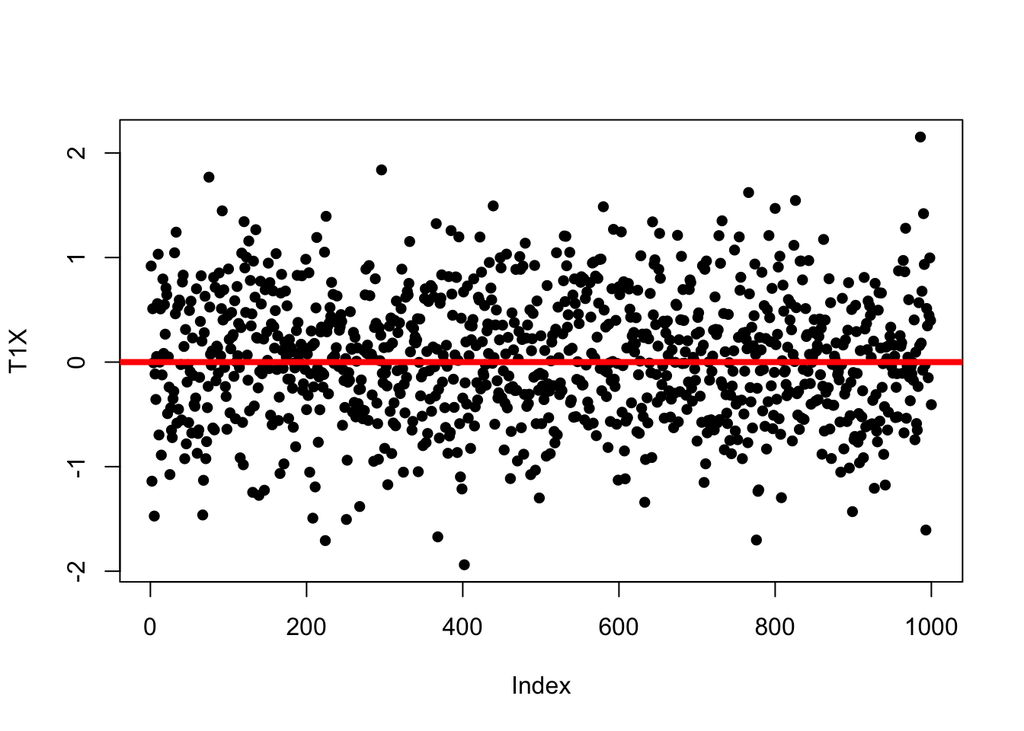

```r
plot(T1X,pch=16)
abline(h=0, col="red",lty=1,lwd=4)
```

### T2 Y T3 Comparemos (RECORDEMOS QUE T2 SI ES INSESGADO)

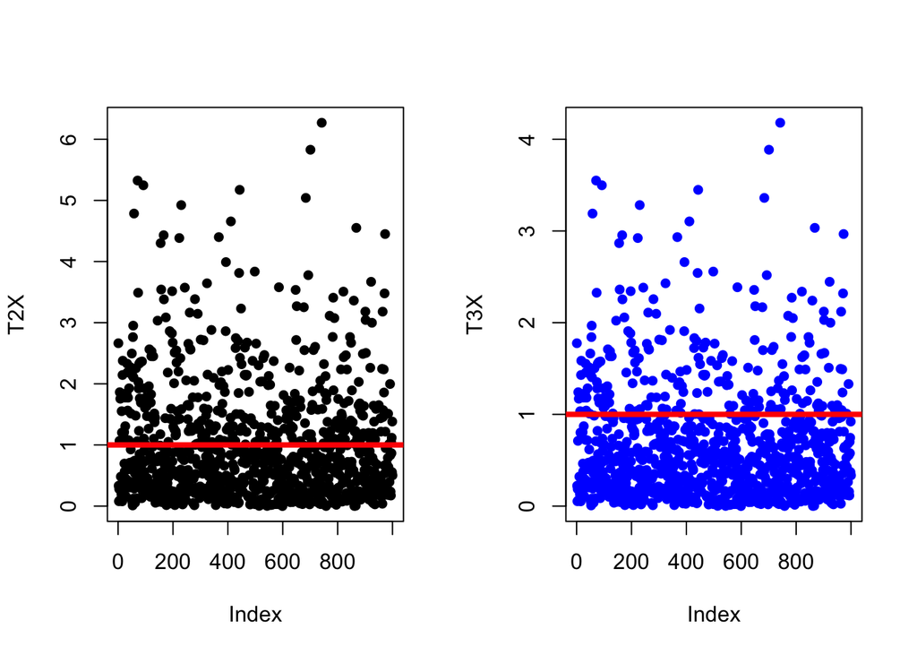

```r
par(mfrow=c(1,2))

plot(T2X,pch=16)
abline(h=1, col="red",lty=1,lwd=4)

plot(T3X,pch=16,col="blue")
abline(h=1, col="red",lty=1,lwd=4)
```

```r
par(mfrow=c(1,1))
```

Qu diferencias se aprecian o que conclusiones podriamos tener?

### Adems veamos el comportamiento asinttico de los estimadores

Recordamos que la consistencia tiene que ver con los tamaos de muestras grandes, es decir, es una propiedad asinttica Un estimador, en general, es consistente si:

Sea $T_1, T_2, ... , T_n$ una sucesin de estimadores de $\tau(\theta)$ donde $T_n$ est basado en una muestra de tamao $n$.

Esta sucesin de estimadores de $\tau(\theta)$ es consistente en error cuadrtico medio si:

$$\displaystyle\lim_{n \to \infty} ECM_{T_n} = 0$$

### Ejemplo

Pensemos en x_1,…,x_n una m.a. de la distribucin $N(\mu,\sigma^2)$. Considere los estimadores $\bar{X}_n$ y $S^2_n$ para $\sigma^2$.

Los dos son consistentes

```r
S2=function(x){
    s2<-(1/length(x))*sum((x-mean(x))^2)
    return(s2)
    }


n<-5000
T1X<-rep(1,n)
T1X<-rep(1,n)

for( i in 2:n){
T1X[i]<-mean(rnorm(i))

T2X[i]<-S2(rnorm(i))

}
```

```r
# plot(T1X,pch=16,xlab="Tama??o de Muestra",ylab="Estimaciüžśźn de T1(X)",main="Xbar Consistente")
# abline(h=0, col="red",lty=1,lwd=4)
#
# plot(T2X,pch=16,xlab="Tama??o de Muestra",ylab="Estimaciüžśźn de T1(X)",main="S^2 Consistente",col="blue")
# abline(h=1, col="red",lty=1,lwd=4)
```